# 04_right_tri_complems_rad

## 04_right_tri_complems_rad

#### Question

1. A right triangle is drawn such that its hypotenuse connects the origin to the edge of the unit circle (which is centered at the origin) in the first quadrant. The acute angle at the origin has a measure of $\frac{\pi}{6}$. What is the measure, in radians, of the other acute angle of the right triangle?

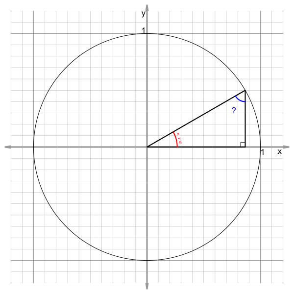

#### Question

2. A right triangle is drawn such that its hypotenuse connects the origin to the edge of the unit circle (which is centered at the origin) in the first quadrant. The acute angle at the origin has a measure of $\frac{\pi}{4}$. What is the measure, in radians, of the other acute angle of the right triangle?

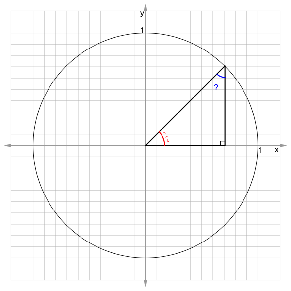

#### Question

3. A right triangle is drawn such that its hypotenuse connects the origin to the edge of the unit circle (which is centered at the origin) in the first quadrant. The acute angle at the origin has a measure of $\frac{\pi}{12}$. What is the measure, in radians, of the other acute angle of the right triangle?

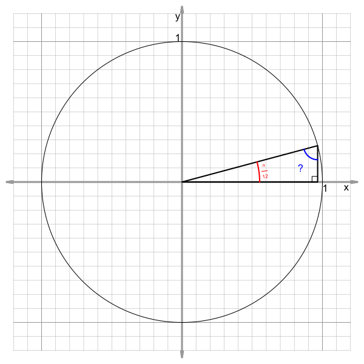

#### Question

4. A right triangle is drawn such that its hypotenuse connects the origin to the edge of the unit circle (which is centered at the origin) in the first quadrant. The acute angle at the origin has a measure of $\frac{\pi}{9}$. What is the measure, in radians, of the other acute angle of the right triangle?

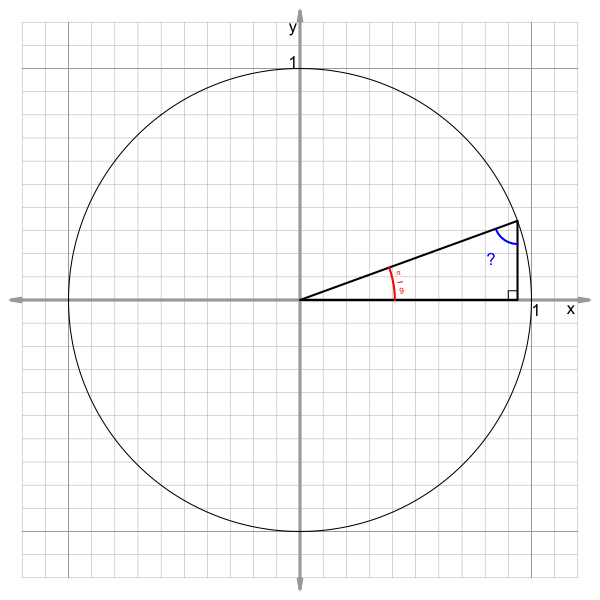

#### Question

5. A right triangle is drawn such that its hypotenuse connects the origin to the edge of the unit circle (which is centered at the origin) in the first quadrant. The acute angle at the origin has a measure of $\frac{13\pi}{36}$. What is the measure, in radians, of the other acute angle of the right triangle?

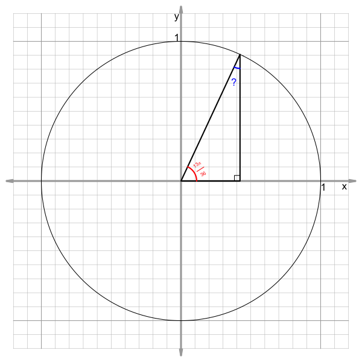

#### Question

6. A right triangle is drawn such that its hypotenuse connects the origin to the edge of the unit circle (which is centered at the origin) in the first quadrant. The acute angle at the origin has a measure of $\frac{\pi}{10}$. What is the measure, in radians, of the other acute angle of the right triangle?

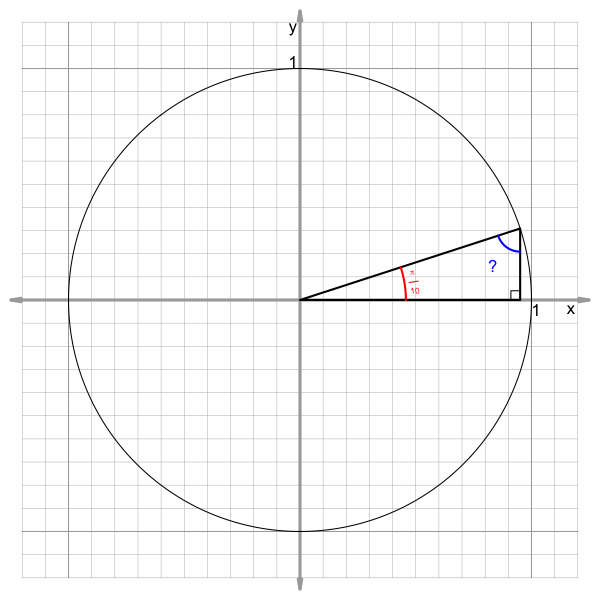

#### Question

7. A right triangle is drawn such that its hypotenuse connects the origin to the edge of the unit circle (which is centered at the origin) in the first quadrant. The acute angle at the origin has a measure of $\frac{3\pi}{10}$. What is the measure, in radians, of the other acute angle of the right triangle?

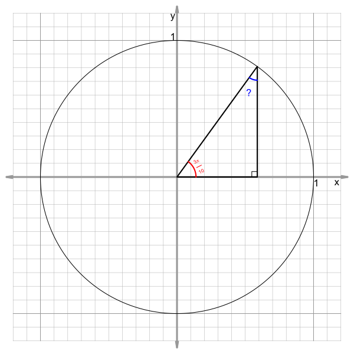

#### Question

8. A right triangle is drawn such that its hypotenuse connects the origin to the edge of the unit circle (which is centered at the origin) in the first quadrant. The acute angle at the origin has a measure of $\frac{7\pi}{20}$. What is the measure, in radians, of the other acute angle of the right triangle?

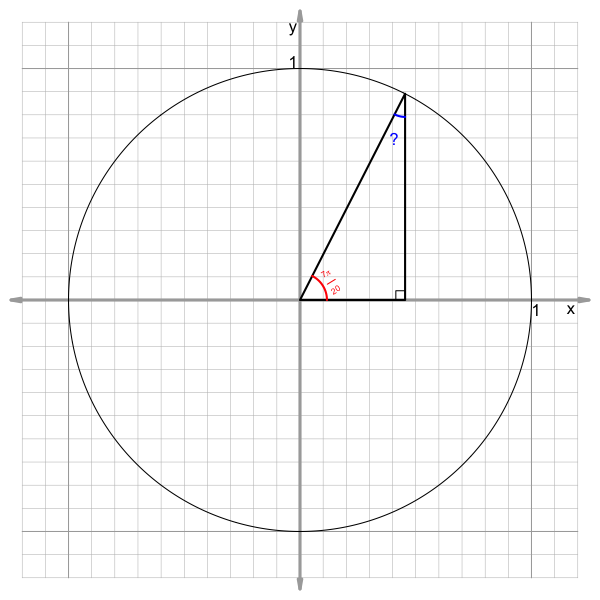